# Application of BEDRT and EDRT on simulated data

Solenne Gaucher

2025-03-31

This markdown illustrate how to run the Estimated Density Ratio Test (EDRT) and its bootstrapped counterpart (BEDRT) described in on simulated data. Note that we assume that the data are in $[0,1]^d$. *To run these tests on real data, the observations should first be normalized.*

### Define the distribution

We simulate data with distributions $f^0$ and $f^1$ corresponding to truncated gaussians. These distributions correspond to the intermediate setting (setting B) in the paper.

```r
################################## Distributions ##############################
s <- matrix(c(1/100, 0, 0, 1/100), ncol = 2, nrow = 2)
# Define distribution f0

rf0 <- function(n){
  m0 <- c(4/10, 4/10)
  return(tmvtnorm::rtmvnorm(n, m0, s, lower = c(0,0), upper = c(1,1)))
}

# Define distribution f1
rf1 <- function(n){
  m0 <- c(6/10, 6/10)
  return(tmvtnorm::rtmvnorm(n, m0, s, lower = c(0,0), upper = c(1,1)))
}
```

### Simulate a dataset

We draw $n^0$ saples from $f^0$ and $n^1$ saples from $f^1$. Then, we separate these samples between samples ussed for choosing the partition, and samples used to estiate $f^0$ and $f^1$ on this partition.

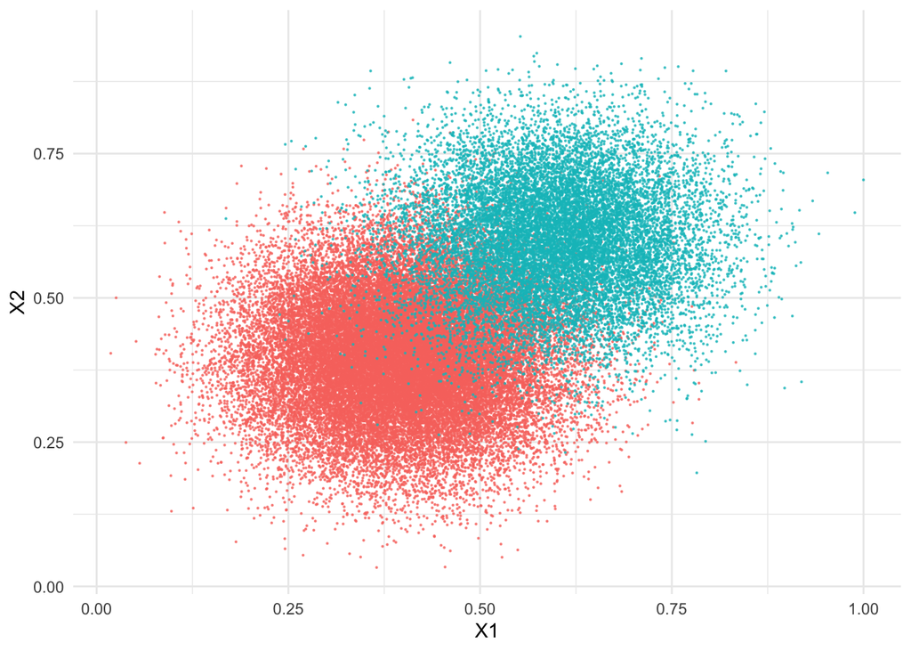

```r
n_train <- 100000 # values for n_train
p0 <- 0.7
n0 <- as.integer(p0*n_train) # number of samples drawn from f0
n1 <- n_train - n0 # number of samples drawn from f1

X0 <- rf0(n0) # Training sample drawn from f0
X1 <- rf1(n1) # Training sample drawn from f1

n0_partition <- floor(nrow(X0))/2 # number of samples drawn from f0 used to choose the partition sequence
n1_partition <- floor(nrow(X1))/2 # number of samples drawn from f1 used to choose the partition sequence
id0_partition <- sample(nrow(X0), n0_partition)
id1_partition <- sample(nrow(X1), n1_partition)
X0_partition <- X0[id0_partition, ] # samples drawn from f0 used to choose the partition
X1_partition <- X1[id1_partition, ] # samples drawn from f1 used to choose the partition
X_partition <- rbind(X0_partition,X1_partition)
data_partition <- data.frame(X_partition)
data_partition$Y <- c(rep(0, n0_partition), rep(1, n1_partition))

n0_estimation <- n0 - n0_partition # number of samples used to estimate f0
n1_estimation <- n1 - n1_partition # number of samples used to estimate f1
X0_estimation <- X0[-id0_partition, ] # samples used to estimate f0
X1_estimation <- X1[-id1_partition, ] # samples used to estimate f1
X_estimation <- rbind(X0_estimation,X1_estimation)
data_estimation <- data.frame(X_estimation)
data_estimation$Y <- c(rep(0, n0_estimation), rep(1, n1_estimation))

# Plot the dataset
ggplot(data = data_partition, aes(x = X1, y = X2)) + geom_point(size = 0.1, aes(color=as.factor(Y)), alpha = 0.7) + theme_minimal() + labs(color="Distribution") + scale_color_discrete(labels = c(expression(f^0), expression(f^1))) + theme(legend.position = "none")
```

### Grow the partition sequence for the test

We choose the partition sequence for the test on the first half of the training set. Note that this requires knowing the test sample size $n$, chosen here to be $n = 0.1 n_train$. We set the paraeterss as specified by our theoretical analysis.

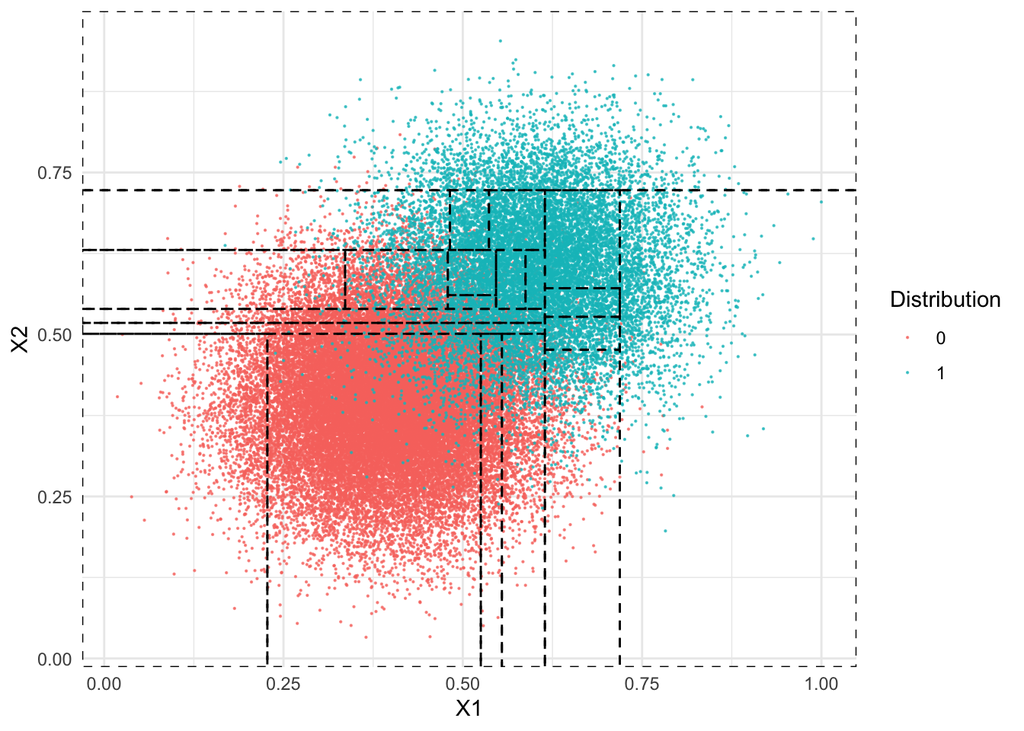

```r
# Define the parameters for growing the partition sequence
n = 0.1*n_train
alpha = 0.05
Kmax <- 15
u <- log(4*Kmax/alpha)
t <- log(2/alpha)
epsilon0 = max(3*u/n0_partition, t/n)
epsilon1 = max(sqrt(3*u/n1_partition),epsilon0)
parms_partition = list(epsilon0 = epsilon0, epsilon1 = epsilon1, n0 = n0_partition, n1 = n1_partition)

# Grow the partition sequence
full_tree <- rpart::rpart(Y ~ X1 + X2, data = data_partition, method = method_dr(), parms = parms_partition, cp = 0, maxdepth = 10, minbucket = sqrt(n1_partition))

full_partition <- as.party(full_tree)
ggplot(data = data_partition, aes(x = X1, y = X2)) +
  geom_point(size = 0.1, aes(color=as.factor(Y)), alpha = 0.7) +
  geom_parttree(data = full_partition, alpha = 0.1, show.legend = FALSE, linetype = "dashed") +
  theme_minimal() + labs(color="Distribution")
```

### Choose the partition in the sequence and estimate the density

We choose the partition in the sequence sequence using the second half of the training sample.

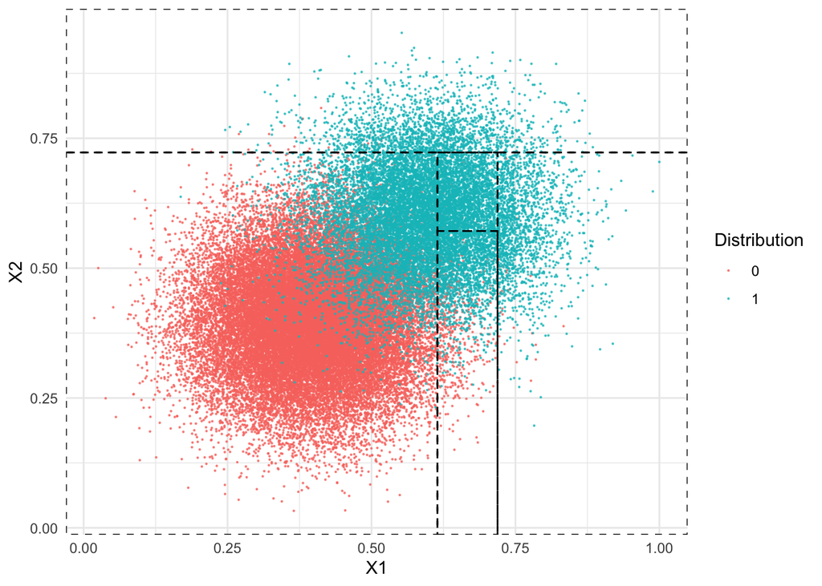

```r
# Define the parameters for choosing the partition
epsilon0 = max(3*u/n0_estimation, t/n)
epsilon1 = max(sqrt(3*u/n1_estimation),epsilon0)
parms_choose_partition = list(epsilon0 = epsilon0, epsilon1 = epsilon1, n0 = n0_estimation, n1 = n1_estimation)

# Choose the partition in the sequence
pruned_tree <- prune_dr(full_tree, data_estimation, parms_choose_partition, Kmin = 3)
partition <- as.party(pruned_tree$pruned_tree)

# Plot the partition
ggplot(data = data_partition, aes(x = X1, y = X2)) + geom_point(size = 0.1, aes(color=as.factor(Y)), alpha = 0.7) +
  geom_parttree(data = partition, alpha = 0.1, show.legend = FALSE, linetype = "dashed") +
  theme_minimal() + labs(color="Distribution")
```

### Compute the threshold for the bootstrap DRT

The number of bootstrap sample is chosen to be 300.

```r
# Set the parameters for estimating f0 and f1
K <- pruned_tree$K
u <- log(4*K/alpha)
t <- log(2/alpha)
epsilon0 = max(3*u/n0_estimation, t/n)
epsilon1 = max(sqrt(3*u/n1_estimation),epsilon0)
parms_estimation = list(epsilon0 = epsilon0, epsilon1 = epsilon1,
                 n0 = n0_estimation, n1 = n1_estimation, n_test = n,
                 u = u, t = t, K = K)
B_iterations <- 300

# Compute the threshold for the  using bootstrap
bootstrap_threshold <- quantile_dr_bootstrap(data_estimation, partition,
                                   parms_estimation, B_iterations, alpha)
```

### Construct a test dataset and run the test

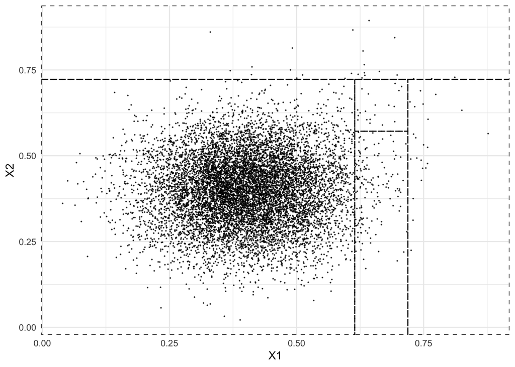

```r
theta = 0.015
n1_test <- as.integer(theta*n)
n0_test <- n - n1_test
if (n1_test>0){
  X_test <- rbind(rf0(n0_test),rf1(n1_test))
}else{
  X_test <- rf0(n0_test)
}
data_test <- as.data.frame(X_test)
names(data_test) <- c("X1", "X2")

# Plot the test data
ggplot(data = data_test, aes(x = X1, y = X2)) + geom_point(size = 0.1, alpha = 0.7) + geom_parttree(data = partition, alpha = 0.1, show.legend = FALSE, linetype = "dashed") +
  theme_minimal()
```

```r
BEDRT <- test_dr_bootstrap(data_estimation, data_test, partition, parms_estimation, bootstrap_threshold)
EDRT <- test_dr(data_estimation, data_test, parms_estimation, partition)
print(paste("According to BEDRT, H0 is", BEDRT != 1))
```

```
## [1] "According to BEDRT, H0 is FALSE"
```

```r
print(paste("According to EDRT, H0 is", EDRT != 1))
```

```
## [1] "According to EDRT, H0 is TRUE"
```